# Data Science Project with App Store Dataset

Harshdeep Kahlon

12/4/2019

## 1. Abstract

The dataset found [here](https://www.kaggle.com/ramamet4/app-store-apple-data-set-10k-apps/downloads/app-store-apple-data-set-10k-apps.zip/7) contains more than 7,000 details about apps that are currently listed on the Apple iOS App Store. By investigating this data, we can potentially find interesting observations that could assist companies and developers to further grow their mobile applications.

## 2. Problem Descriptions and Objectives

The goal of this project is to analyze the App Store data and discover if genre, price, and/or content rating are vital in determining the success of an app. Once the attributes have been found, this project will try to classify whether or not a successful app needs a high user rating. This project will also explore the relationship between an app’s size in megabytes and the genre of it. Finally, this project will compare free apps to paid apps ($0.99 and above) and find any major differences.

## 3. Data Description

- X - Position of each app in the dataset.
- id - Unique identifier for each app.
- track_name - Name as it appear’s on the App Store
- size_bytes - Total downlaad size in bytes
- currency - The primary currency type of each app
- price - Total price in USD
- rating_count_tot - Rating count for all versions
- rating_count_ver - Rating count for its current version
- user_rating - Average rating value for all versions
- user_rating_ver - Average rating value for its current version
- ver - Each app’s latest version identifier
- cont_rating - Content rating. Ex. 9+, 12+, 17+
- prime_genre - Primary genre in the App Store
- sup_devices.num - Each app’s number of supported devices
- ipadSc_urls.num - Number of screenshots allowed to display
- lang.num - Number of supported languages
- vpp_lic - VPP device-based licensing is or is not enabled

## 4. Loading and Formatting Data

I first imported the App Store Dataset and found some useful variables to be missing. I created “size_mb” to measure the each app’s size in megabytes rather than bytes. I created “is_free” as a Boolean expression to see if each app is free or not. I created “user_rating_string” since there were only 10 possible values for each app’s user rating.

```r
appstore_df <- read.csv("../Data/AppleStore.csv")
appstore_df <- mutate(appstore_df, size_mb = size_bytes/1000000)
appstore_df <- mutate(appstore_df, is_free = price == 0)
appstore_df <- mutate(appstore_df, user_rating_string = as.character(user_rating))
appstore_df %>% arrange(X)
```

| X | id | track_name | size_bytes | currency | price | rating_count_tot | rating_count_ver | user_rating | user_rating_ver | ver | cont_rating | prime_genre | sup_devices.num | ipadSc_urls.num | lang.num | vpp_lic | size_mb | is_free | user_rating_string |
| --- | --- | --- | --- | --- | --- | --- | --- | --- | --- | --- | --- | --- | --- | --- | --- | --- | --- | --- | --- |
| 1 | 281656475 | PAC-MAN Premium | 100788224 | USD | 3.99 | 21292 | 26 | 4.0 | 4.5 | 6.3.5 | 4+ | Games | 38 | 5 | 10 | 1 | 100.788224 | FALSE | 4 |
| 2 | 281796108 | Evernote - stay organized | 158578688 | USD | 0.00 | 161065 | 26 | 4.0 | 3.5 | 8.2.2 | 4+ | Productivity | 37 | 5 | 23 | 1 | 158.578688 | TRUE | 4 |
| 3 | 281940292 | WeatherBug - Local Weather, Radar, Maps, Alerts | 100524032 | USD | 0.00 | 188583 | 2822 | 3.5 | 4.5 | 5.0.0 | 4+ | Weather | 37 | 5 | 3 | 1 | 100.524032 | TRUE | 3.5 |
| 4 | 282614216 | eBay: Best App to Buy, Sell, Save! Online Shopping | 128512000 | USD | 0.00 | 262241 | 649 | 4.0 | 4.5 | 5.10.0 | 12+ | Shopping | 37 | 5 | 9 | 1 | 128.512000 | TRUE | 4 |
| 5 | 282935706 | Bible | 92774400 | USD | 0.00 | 985920 | 5320 | 4.5 | 5.0 | 7.5.1 | 4+ | Reference | 37 | 5 | 45 | 1 | 92.774400 | TRUE | 4.5 |
| 6 | 283619399 | Shanghai Mahjong | 10485713 | USD | 0.99 | 8253 | 5516 | 4.0 | 4.0 | 1.8 | 4+ | Games | 47 | 5 | 1 | 1 | 10.485713 | FALSE | 4 |
| 7 | 283646709 | PayPal - Send and request money safely | 227795968 | USD | 0.00 | 119487 | 879 | 4.0 | 4.5 | 6.12.0 | 4+ | Finance | 37 | 0 | 19 | 1 | 227.795968 | TRUE | 4 |
| 8 | 284035177 | Pandora - Music & Radio | 130242560 | USD | 0.00 | 1126879 | 3594 | 4.0 | 4.5 | 8.4.1 | 12+ | Music | 37 | 4 | 1 | 1 | 130.242560 | TRUE | 4 |
| 9 | 284666222 | PCalc - The Best Calculator | 49250304 | USD | 9.99 | 1117 | 4 | 4.5 | 5.0 | 3.6.6 | 4+ | Utilities | 37 | 5 | 1 | 1 | 49.250304 | FALSE | 4.5 |
| 10 | 284736660 | Ms. PAC-MAN | 70023168 | USD | 3.99 | 7885 | 40 | 4.0 | 4.0 | 4.0.4 | 4+ | Games | 38 | 0 | 10 | 1 | 70.023168 | FALSE | 4 |

[output cut: 7187 more lines]

## 5. Data Visualization and EDA

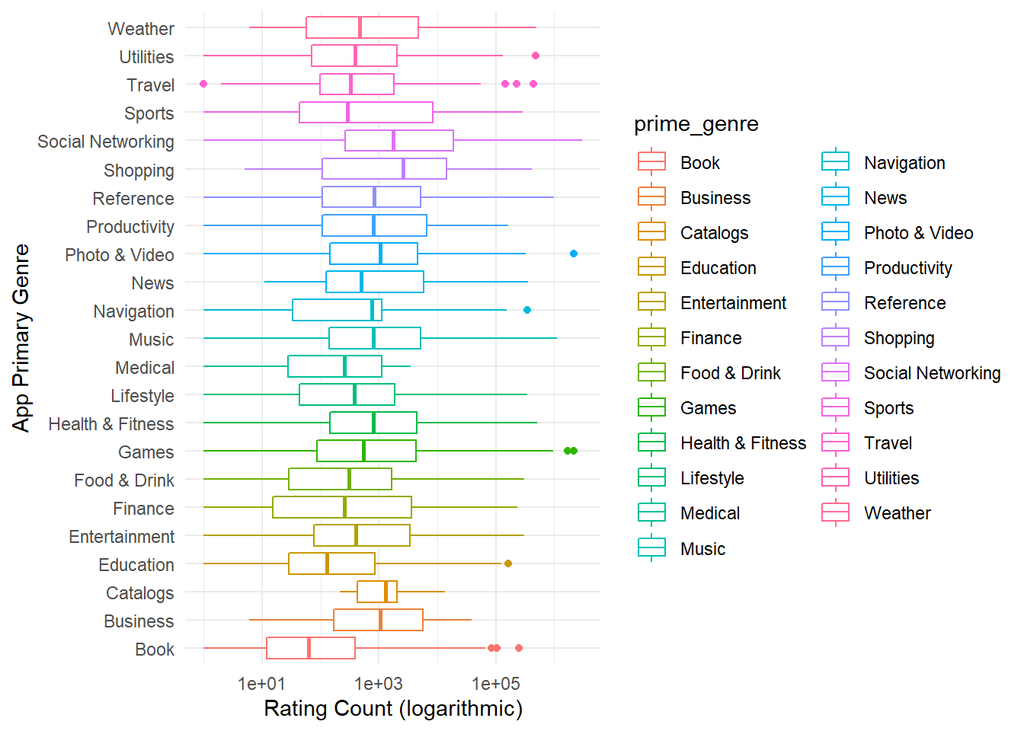

Since a total downlaod count is not available in this dataset due to restrictions from Apple, we will treat the total rating count of an app to be a rough estimate of its total downloads. A higher rating count implies that the app is more successful. We can see how the popularity of every app genre with the graph above. The app genre plays a minor impact in the success of an app (exception is the Book genre).

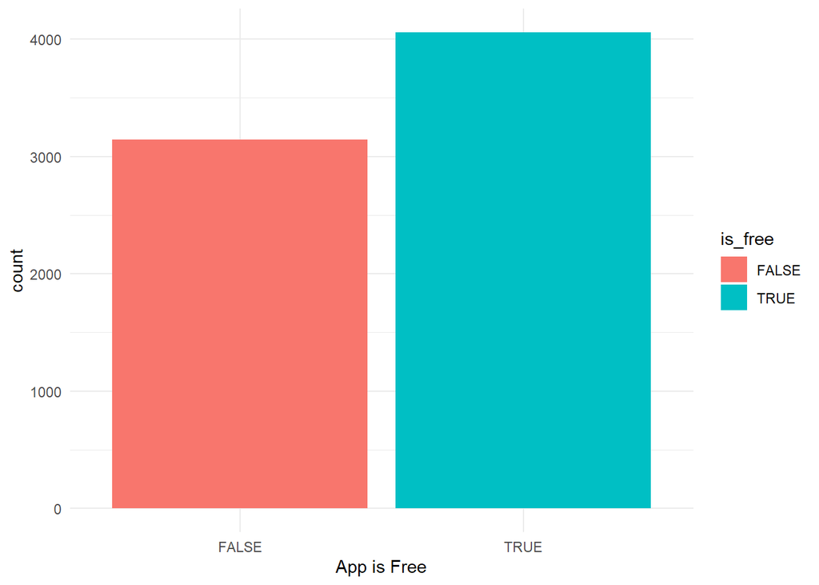

We can see that there are more free apps in the Apple App Store than paid apps, which can range from $0.99 to $299.99.

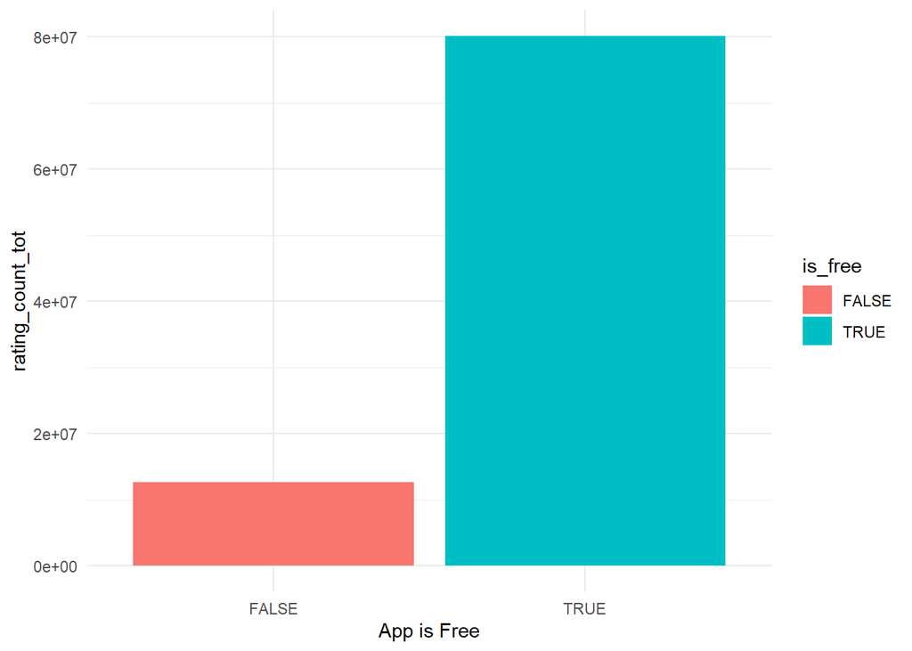

The total rating count, which implies the total download count, of free apps are much higher than paid apps. This ratio is significantly higher than the number of free apps to paid apps, which implies that free apps are typically more successful in the App Store.

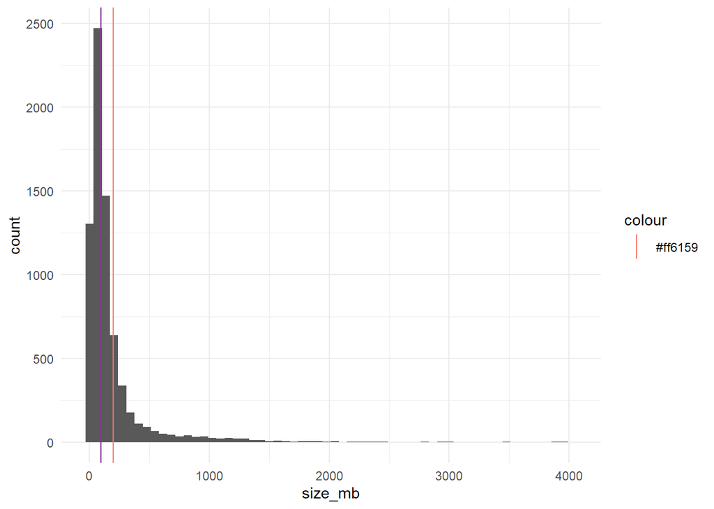

We can see the distribution of the app sizes throughout the ~7000 apps in the data set. The red line represents the mean of the app sizes in megabytes, while the purple line represents the median of the app sizes in megabytes. We can see that most apps are under the 500 MB threshold.

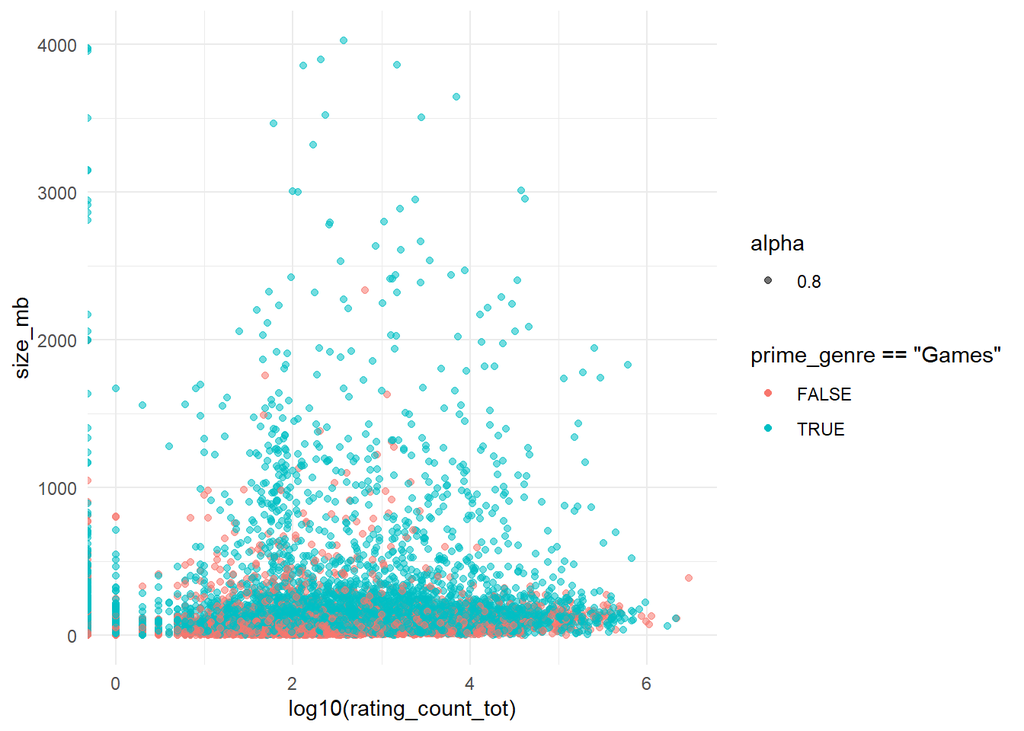

This scatterplot outlines many aspects about the data that we’re investigating. The most striking aspect is that most of the apps in the dataset fall into the Games category, as you can see with the blue coloring. Also, most of the apps with greater than 1 GB download size are in fact games. Every other app category mostly falls under the 1 GB download size. In addition, the super-popular apps to the far right of the graph typically do not exceed the 2 GB threshold.

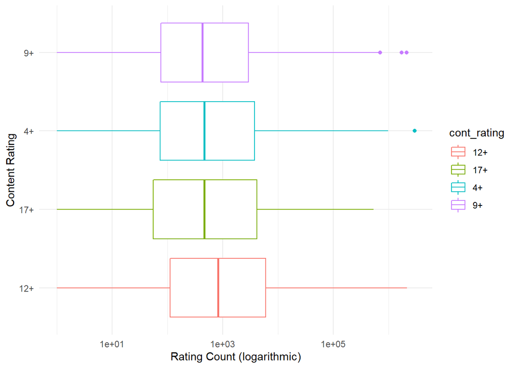

We could see that content rating plays a very minor roll in determining the success of an app.

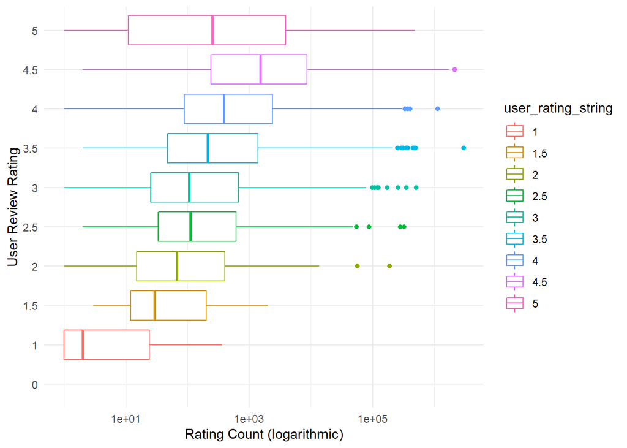

# 6. Modeling

Two models were created for this dataset. We will first analyze the Ridge Regression model.

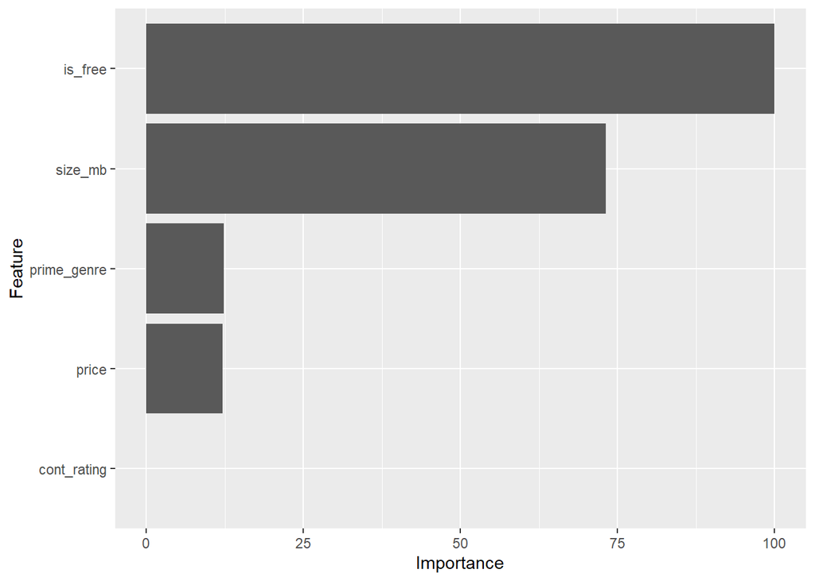

According to the Ridge Regression variable importance plot, the most important factors in determining an app’s success (total rating count) is if the app was free or not. Second is the app’s total size in megabytes. The actual price of the app has a slight affect of the overall rating count if the app is paid. The prime genre also has slight importance. However, the content rating of the app is not important at all in determining the overall rating count.

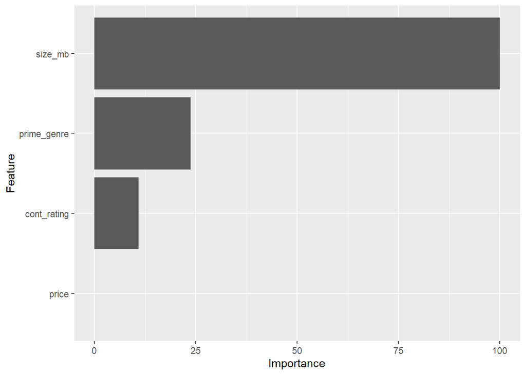

The GBM variable importance plot does not contain if the app is free or not, but does contain the rest of the predictors. The most important variable in this is the app’s total download size. The prime genre of the app has slight importance as as well. Where this differs from the Ridge Regression model is the importance of content rating and price with both variables having swapped postiion from the Ridge Regression model.

# 7. Conclusion